# LendingClub: Predicting Loan Defaults

6 June 2019

## Background

LendingClub is a peer-to-peer lending platform established in the US in 2006. Borrowers can request unsecured personal loans between $1,000 and $40,000 from potential investors.

LendingClub had a strong start, raising $1 billion in the 2014 initial public offering but ran into some investment issues in 2016 as well as an internal scandal regarding the CEO Renaud Laplanche.

You can download several datasets from the LendinClub website about lenders and borrowers using the platform. I decided to see if we could use some of the variables to predict if someone has paid back their loan in full.

## Dataset

```
## [1] 9578   14
```

So we have about 10,000 observations, 13 predictor variables and one binary response variable 'not.fully.paid'.

0 = loan has been fully paid.

1 = loan has not been fully paid.

## Variables

[output not shown]

## Variables (cont.)

| Variable | Description |
| --- | --- |
| days.with.cr.line | The number of days the borrower has had a credit line. |
| revol.bal | The borrower's revolving balance (amount unpaid at the end of the credit card billing cycle). |
| revol.util | The borrower's revolving line utilization rate (the amount of the credit line used relative to total credit available). |
| inq.last.6mths | The borrower's number of inquiries by creditors in the last 6 months. |
| delinq.2yrs | The number of times the borrower had been 30+ days past due on a payment in the past 2 years. |
| pub.rec | The borrower's number of derogatory public records (bankruptcy filings, tax liens, or judgments). |

## Exploration

Lower credit scores appear to have more loans in general - the data appears to be a positively skewed multimodal distribution (light blue = fully paid, dark blue = not fully paid).

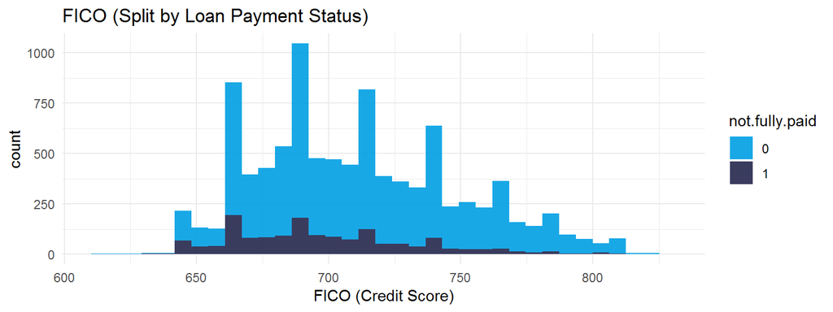

Lots of debt consolidation loans - there doesn't appear to be much difference between the groups in terms of loan payment status

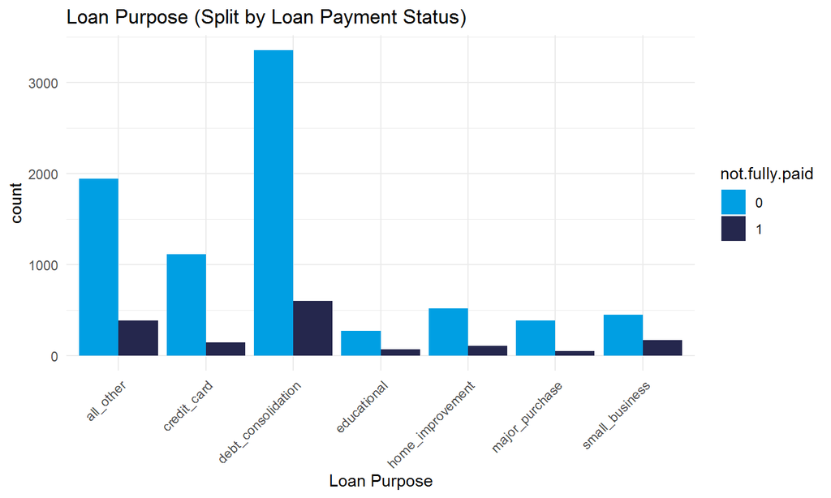

As expected, lower FICO/credit scores result in higher interest rates. There doesn't appear to be any distinct difference in loan payment status groups.

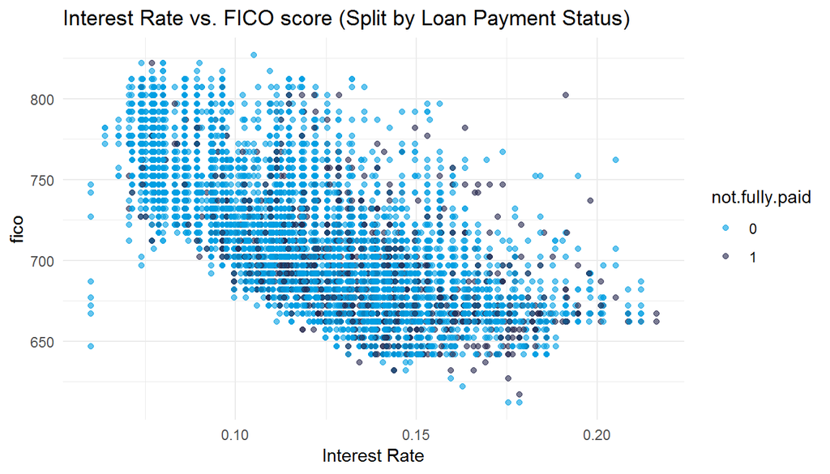

If we look at the distribution between loan status we can see that there are alot more people paying the full loan than those who are charged off.

We have an imbalanced response variable meaning that I will have upsample the minority class ('oversampling') during the train/test split.

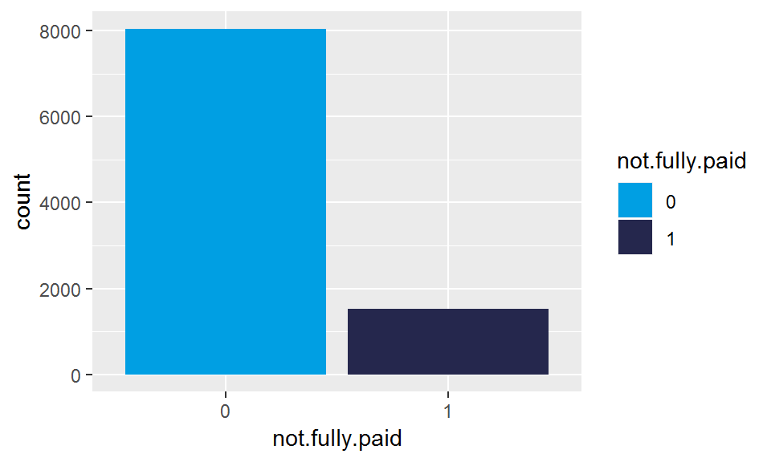

Slightly higher median debt-to-income ratio for those who have not fully paid their loan off.

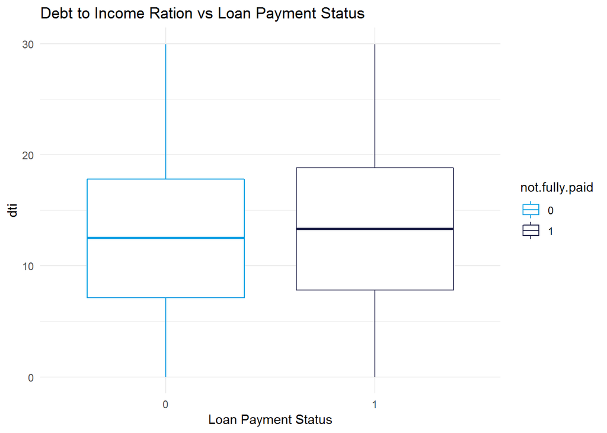

Let's check the completeness and variance inflation factors (VIF) of the dataset. No missing values and VIF < 4 which means we probably don't have multi-collinearity issues.

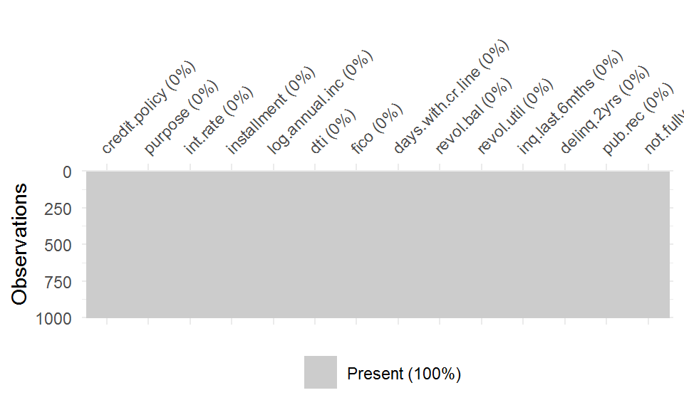

```r
which(multi.col$VIF>4)
```

```
## integer(0)
```

## Model 1

Let's first try a Support Vector Machine (SVM) model. I've tried going to try a 70/30 split for the train and test datasets.

I need to oversample the minority class (those who haven't paid) - the class split looks alot better now in our training set

```r
#over sampling minority class
loan_train_oversample <- ovun.sample(not.fully.paid~., data=loan_train, method="over")$data

#the split is looking good now.
table(loan_train_oversample$not.fully.paid)
```

```
##
##    0    1
## 5632 5659
```

Once i've trained the model I then use it to predict the values in our test set. Here's a table of predicted vs actual results.

```r
table(predicted.svm, loan_test$not.fully.paid, dnn = c("Predicted","Actual"))
```

```
##          Actual
## Predicted    0    1
##         0 1878  323
##         1  535  136
```

The model has done well in predicting those that will pay off their loan (0's), but not so well for those that won't (1's). Let's take a look at the ROC and AUC.

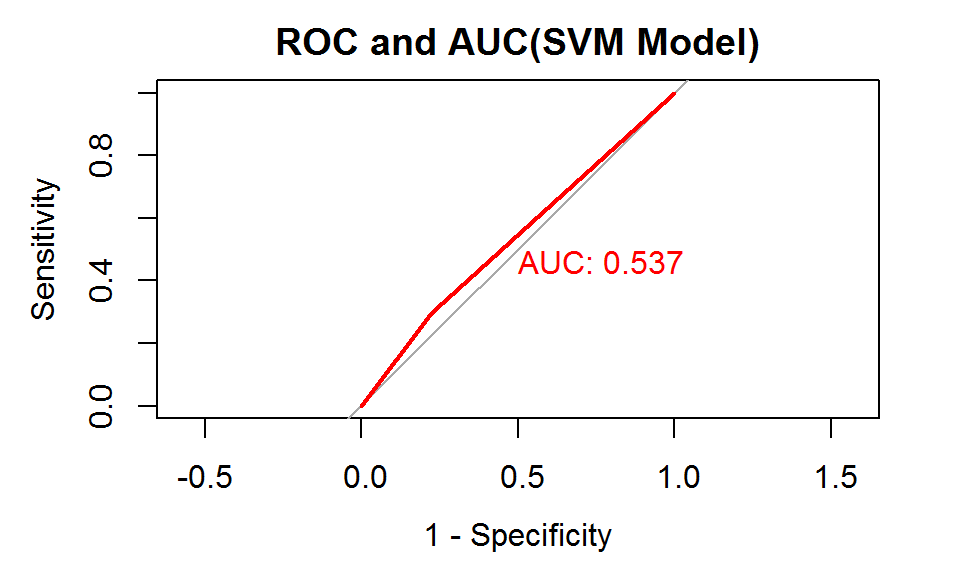

```r
plot(roc.svm,legacy.axes=T,print.auc=T, col="red",main="ROC and AUC(SVM Model)")
```

The ROC curve is a performance metric for classification problems. The higher the area under the curve (AUC) is, the better the model is at predicting 0's as 0's and 1's as 1's. So, this model isn't very good at discriminating between our two classes. Let's try something else.

## Model 2

Let's fit a logistic regression model. I'll use the same 70/30 split, and create a prediction cutoff so that if the model predicts a value>0.5 it becomes 1 and 0 otherwise.

Here's a table of the predicted vs actual results.

```r
table(loan_test$not.fully.paid,pred_cut_off)
```

```
##    pred_cut_off
##        0    1
##   0 1588  825
##   1  202  257
```

```
## [1] 0.6090074
```

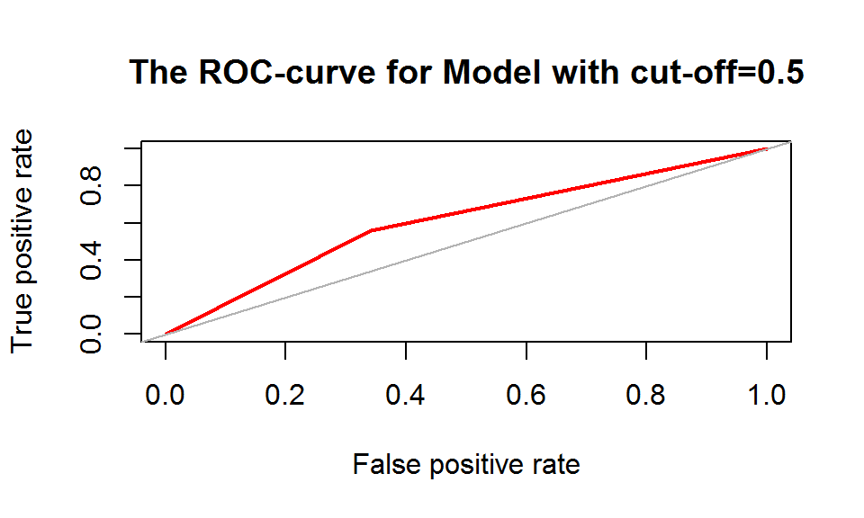

```
## Area under the curve (AUC): 0.609
```

```r
#ROC Curve
roc.curve(loan_test$not.fully.paid, pred_cut_off, col="red", main="The ROC-curve for Model with cut-off=0.5")
```

## Summary

The first model (SVM) had an AUC of 0.537 and the second logistic regression model had a slightly better AUC of 0.61.

A perfect model would have an AUC of 1, whereas an AUC of 0.5 would be similar to tossing a coin - so both models aren't fantastic…

Although I looked online and I think the highest AUC I could find was about 0.7 for this dataset

## Lessons learnt?

1. Choose an easy dataset, especially for an interview workshop :)
2. Don't always jump to the fancy models - I spent alot of time trying to tune the SVM model when I should have started with the logistic regression model and might have had time to explore other models.

## Next Steps & Questions?

- Random Forest, GBM, Ensemble models
- Feature engineering
- Use the full dataset (I found a cut-down version online to save me time on the computation)